# revealjsをslidifyで

竹林 由武

# Reveal.js

### HTML PRESENTATIONS MADE EASY

- 竹林
- 由武

Some notes on the first slide

## Heads Up

reveal.js is a framework for easily creating beautiful presentations using HTML. You’ll need a browser with support for CSS 3D transforms to see it in its full glory.

## Vertical Slides

Slides can be nested inside of other slides, try pressing down

## Basement Level 1

Press down or up to navigate.

## Basement Level 2

Cornify

[figure not shown]

## Basement Level 3

That’s it, time to go back up.

## Vertical Slides

Slides can be nested inside of other slides, try pressing down

## Basement Level 1

Press down or up to navigate.

## Basement Level 2

Cornify

## Point of View

Press ESC to enter the slide overview. Hold down alt and click on any element to zoom in on it using [zoom.js](http://lab.hakim.se/zoom-js). Alt + click anywhere to zoom back out.

## RVL.IO

If you don’t like writing slides in HTML you can use the online editor rvl.io.

## Works in Mobile Safari

Try it out! You can swipe through the slides and pinch your way to the overview.

## Marvolous Unordered List

- No order here
- Or here
- Or here
- Or here

## Fantastic Ordered List

1. One is smaller than…
2. Two is smaller than…
3. Three!

## TRANSITION STYLES

You can select from different transitions, like:

Cube - Page - Concave - Zoom - Linear - Fade - None - Default

## Themes

Reveal.js comes with a few themes built in:

Sky - Beige - Simple - Serif - Night - Default - Solarized - Moon

* Theme demos are loaded after the presentation which leads to flicker. In production you should load your theme in the `<head>` using a `<link>`.

## Global State

Set `data-state="something"` on a slide and “something” will be added as a class to the document element when the slide is open. This lets you apply broader style changes, like switching the background.

## Custom Events

Additionally custom events can be triggered on a per slide basis by binding to the data-state name.

```
Reveal.addEventListener( 'customevent', function() {
  console.log( '"customevent" has fired' );
} );
```

## Clever Quotes

These guys come in two forms, inline: The nice thing about standards is that there are so many to choose from and block:

> For years there has been a theory that millions of monkeys typing at random on millions of typewriters would reproduce the entire works of Shakespeare. The Internet has proven this theory to be untrue.

## Pretty Code

```
function linkify( selector ) {
  if( supports3DTransforms ) {

    var nodes = document.querySelectorAll( selector );

    for( var i = 0, len = nodes.length; i < len; i++ ) {
      var node = nodes[i];

      if( !node.className ) ) {
        node.className += ' roll';
      }
    };
  }
}
```

Courtesy of [highlight.js](http://softwaremaniacs.org/soft/highlight/en/description/)

## Fragmented Views

Hit the next arrow…

> - any type
> - of view
> - **fragments**

## Take a Moment

Press b or period on your keyboard to enter the ‘paused’ mode. This mode is helpful when you want to take distracting slides off the screen during a presentation.

## Title

This is a slide

- point 1
- point 2
- point 3

## Code with slide

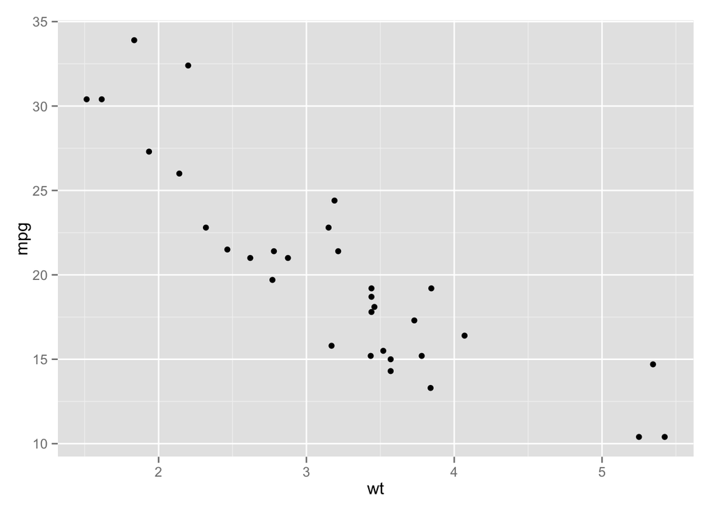

```r
library(ggplot2)
qplot(wt, mpg, data = mtcars)
```

## Vertical Slides

The next set of slides will be vertical slides.

## Slide 1

This is slide 1

## Slide 2

[interactive chart not shown]